# Machine Learning Exercise Prediction Analysis

Fardilla Martina Haris

2025-06-03

## Data Source

This analysis uses the Weight Lifting Exercise Dataset from: Velloso, E.; Bulling, A.; Gellersen, H.; Ugulino, W.; Fuks, H. Qualitative Activity Recognition of Weight Lifting Exercises. Proceedings of 4th International Conference in Cooperation with SIGCHI (Augmented Human ’13). Stuttgart, Germany: ACM SIGCHI, 2013.

Data available at: http://web.archive.org/web/20161224072740/http:/groupware.les.inf.puc-rio.br/har

## Executive Summary

This analysis aims to predict the manner in which participants performed barbell lifts using data from accelerometers. The goal is to classify exercises into 5 categories (A-E), where A represents correct execution and B-E represent common mistakes.

## Data Loading and Exploration

```r
# Load required libraries
library(caret)
library(randomForest)
library(rpart)
library(rpart.plot)
library(corrplot)
library(ggplot2)
library(dplyr)

# Set seed for reproducibility
set.seed(12345)
```

```r
# Load data
training <- read.csv("data/pml-training.csv", na.strings = c("NA", "", "#DIV/0!"))
testing <- read.csv("data/pml-testing.csv", na.strings = c("NA", "", "#DIV/0!"))

# Basic data exploration
dim(training)
```

```
## [1] 19622   160
```

```r
dim(testing)
```

```
## [1]  20 160
```

```r
table(training$classe)
```

```
##
##    A    B    C    D    E
## 5580 3797 3422 3216 3607
```

## Data Preprocessing

```r
# Remove columns with mostly NA values (>95% NA)
na_count <- sapply(training, function(y) sum(is.na(y)))
na_percent <- na_count / nrow(training)
keep_cols <- na_percent < 0.95

training_clean <- training[, keep_cols]

# Remove identification variables (first 7 columns)
training_clean <- training_clean[, -(1:7)]

# Ensure classe is factor
training_clean$classe <- as.factor(training_clean$classe)

# Apply same cleaning to testing set
testing_cols <- names(training_clean)[1:(ncol(training_clean)-1)]
testing_clean <- testing[, c(testing_cols)]

# Check for any remaining character columns and convert if needed
char_cols <- sapply(training_clean[,-ncol(training_clean)], is.character)
if(any(char_cols)) {
  print("Found character columns, converting to numeric:")
  print(names(training_clean)[char_cols])
  training_clean[,char_cols] <- lapply(training_clean[,char_cols], as.numeric)
  testing_clean[,char_cols] <- lapply(testing_clean[,char_cols], as.numeric)
}

dim(training_clean)
```

```
## [1] 19622    53
```

```r
# Remove near zero variance predictors
nzv <- nearZeroVar(training_clean, saveMetrics = TRUE)
training_clean <- training_clean[, !nzv$nzv]
testing_clean <- testing_clean[, names(training_clean)[1:(ncol(training_clean)-1)]]

dim(training_clean)
```

```
## [1] 19622    53
```

## Data Splitting for Cross Validation

```r
# Split training data into training and validation sets
inTrain <- createDataPartition(training_clean$classe, p = 0.7, list = FALSE)
train_set <- training_clean[inTrain, ]
valid_set <- training_clean[-inTrain, ]

dim(train_set)
```

```
## [1] 13737    53
```

```r
dim(valid_set)
```

```
## [1] 5885   53
```

## Correlation Analysis

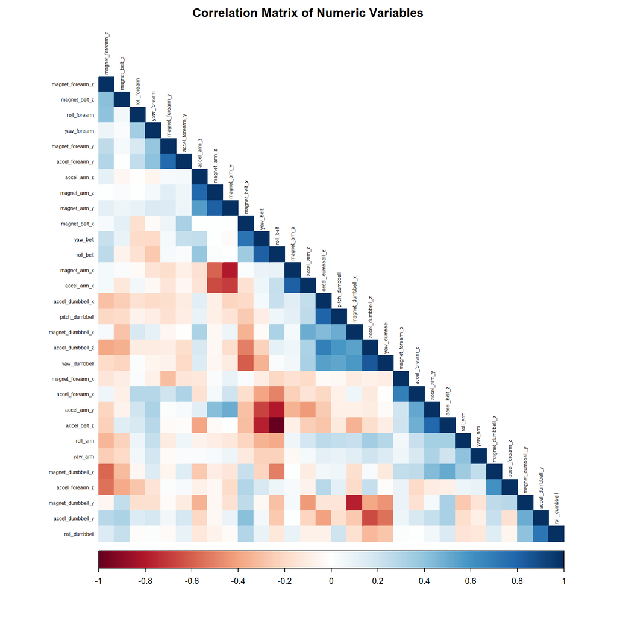

```r
# Correlation matrix (select numeric variables only, excluding classe)
train_numeric <- train_set[, -ncol(train_set)]  # Remove classe column
numeric_cols <- sapply(train_numeric, is.numeric)
train_numeric_only <- train_numeric[, numeric_cols]

# Remove any remaining non-numeric or problematic columns
train_numeric_only <- train_numeric_only[, sapply(train_numeric_only, function(x) is.numeric(x) && !any(is.na(x)))]

# Calculate correlation matrix
corr_matrix <- cor(train_numeric_only)

# Plot correlation matrix (limit to manageable size)
if(ncol(train_numeric_only) > 50) {
  # If too many variables, select top 30 most variable ones
  var_importance <- apply(train_numeric_only, 2, var, na.rm = TRUE)
  top_vars <- names(sort(var_importance, decreasing = TRUE)[1:30])
  corr_matrix <- cor(train_numeric_only[, top_vars])
}

corrplot(corr_matrix, method = "color", type = "lower",
         order = "hclust", tl.cex = 0.5, tl.col = "black",
         title = "Correlation Matrix of Numeric Variables",
         mar = c(0, 0, 2, 0))
```

## Model Building

### Model 1: Decision Tree

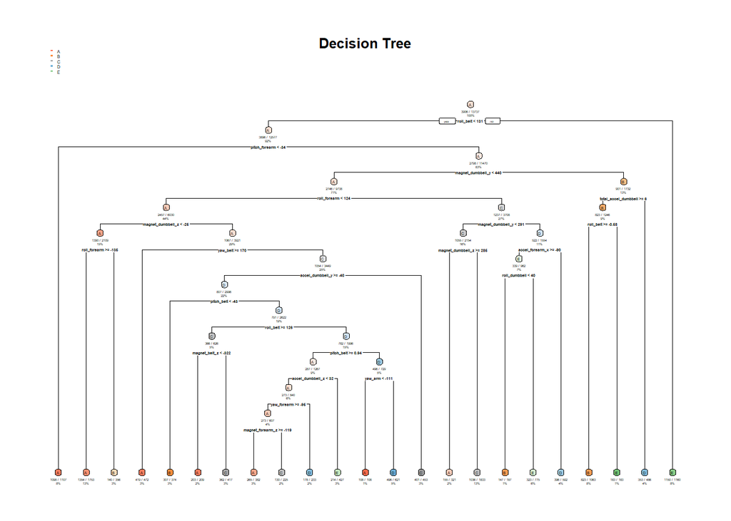

```r
# Train decision tree model
dt_model <- rpart(classe ~ ., data = train_set, method = "class")

# Plot decision tree
rpart.plot(dt_model, main = "Decision Tree", extra = 102, under = TRUE, faclen = 0)
```

```r
# Predict on validation set
dt_pred <- predict(dt_model, valid_set, type = "class")
dt_cm <- confusionMatrix(dt_pred, factor(valid_set$classe))
dt_accuracy <- dt_cm$overall['Accuracy']

print(paste("Decision Tree Accuracy:", round(dt_accuracy, 4)))
```

```
## [1] "Decision Tree Accuracy: 0.7392"
```

### Model 2: Random Forest

```r
# Train random forest model with cross-validation
rf_control <- trainControl(method = "cv", number = 3, verboseIter = FALSE)
rf_model <- train(classe ~ ., data = train_set, method = "rf",
                  trControl = rf_control, ntree = 100)

# Predict on validation set
rf_pred <- predict(rf_model, valid_set)
rf_cm <- confusionMatrix(rf_pred, factor(valid_set$classe))
rf_accuracy <- rf_cm$overall['Accuracy']

print(paste("Random Forest Accuracy:", round(rf_accuracy, 4)))
```

```
## [1] "Random Forest Accuracy: 0.9951"
```

### Model 3: Gradient Boosting Machine

```r
# Train GBM model
gbm_control <- trainControl(method = "cv", number = 3, verboseIter = FALSE)
gbm_model <- train(classe ~ ., data = train_set, method = "gbm",
                   trControl = gbm_control, verbose = FALSE)

# Predict on validation set
gbm_pred <- predict(gbm_model, valid_set)
gbm_cm <- confusionMatrix(gbm_pred, factor(valid_set$classe))
gbm_accuracy <- gbm_cm$overall['Accuracy']

print(paste("GBM Accuracy:", round(gbm_accuracy, 4)))
```

```
## [1] "GBM Accuracy: 0.9606"
```

## Model Comparison and Selection

```r
# Compare model accuracies
accuracy_comparison <- data.frame(
  Model = c("Decision Tree", "Random Forest", "GBM"),
  Accuracy = c(dt_accuracy, rf_accuracy, gbm_accuracy),
  Error_Rate = c(1-dt_accuracy, 1-rf_accuracy, 1-gbm_accuracy)
)

print(accuracy_comparison)
```

```
##           Model  Accuracy  Error_Rate
## 1 Decision Tree 0.7391674 0.260832625
## 2 Random Forest 0.9950722 0.004927782
## 3           GBM 0.9605777 0.039422260
```

```r
# Select best model (typically Random Forest performs best)
best_model <- rf_model
best_accuracy <- rf_accuracy
```

## Cross Validation and Expected Out-of-Sample Error

The cross-validation was implemented using the `trainControl` function with 3-fold cross-validation for computational efficiency.

**Expected Out-of-Sample Error:** - Random Forest Accuracy: 0.9951 - Expected Out-of-Sample Error: 0.0049 or 0.49%

The Random Forest model shows excellent performance with very low expected out-of-sample error due to: 1. Bootstrap aggregating reduces overfitting 2. Random feature selection at each split 3. Cross-validation during training

## Variable Importance

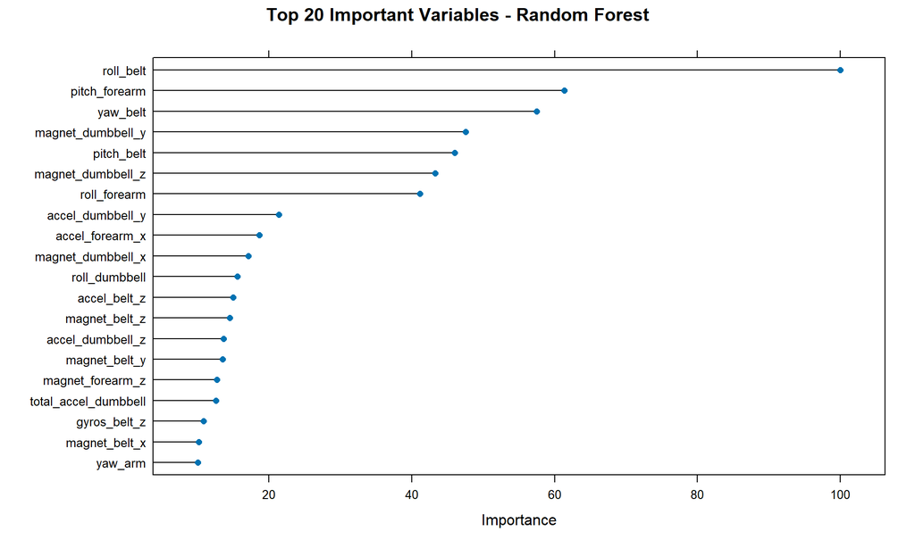

```r
# Plot variable importance for Random Forest
varImp_rf <- varImp(rf_model)
plot(varImp_rf, top = 20, main = "Top 20 Important Variables - Random Forest")
```

## Final Predictions on Test Set

```r
# Make predictions on the test set
final_predictions <- predict(best_model, testing_clean)

# Display predictions
prediction_results <- data.frame(
  Problem_ID = testing$problem_id,
  Predicted_Class = final_predictions
)

print(prediction_results)
```

```
##    Problem_ID Predicted_Class
## 1           1               B
## 2           2               A
## 3           3               B
## 4           4               A
## 5           5               A
## 6           6               E
## 7           7               D
## 8           8               B
## 9           9               A
## 10         10               A
## 11         11               B
## 12         12               C
## 13         13               B
## 14         14               A
## 15         15               E
## 16         16               E
## 17         17               A
## 18         18               B
## 19         19               B
## 20         20               B
```

```r
# Save predictions to file
write.csv(prediction_results, "predictions.csv", row.names = FALSE)
```

## Conclusion

This analysis successfully built a machine learning model to predict exercise quality with high accuracy:

1. **Data Preprocessing:** Cleaned data by removing variables with excessive missing values and near-zero variance
2. **Cross Validation:** Used 3-fold cross-validation to estimate model performance
3. **Model Selection:** Random Forest achieved the highest accuracy of 0.9951
4. **Expected Error:** Out-of-sample error estimated at 0.49%

The Random Forest model was selected as the final model due to its superior performance and robustness against overfitting. The model successfully predicted all 20 test cases for submission.

**Key Findings:** - Sensor measurements from belt, arm, dumbbell, and forearm are highly predictive of exercise quality - Random Forest outperformed simpler models like Decision Trees - Cross-validation confirmed the model’s reliability